# Estimating Likelihood

# Excrcise: claculate tree likelihood

Try coding your own Likelihood algorithm that calculates likelihood of a state pattern given: (1) tree, (2) rate matrix with specified parameters, and (3) specified initial vector of probabilities at tree root. Make this algorithm working for a 3-taxon tree. Your toy algorithm should work like the Felsentein’s pruning algorithm from today’s lecture. Use binary characters for brevity.

Before, coding the Ln algorithm, simulate a tree and note the main data structures that store the tree topology and branch lengths

```r
library(ape)
library(phytools)
```

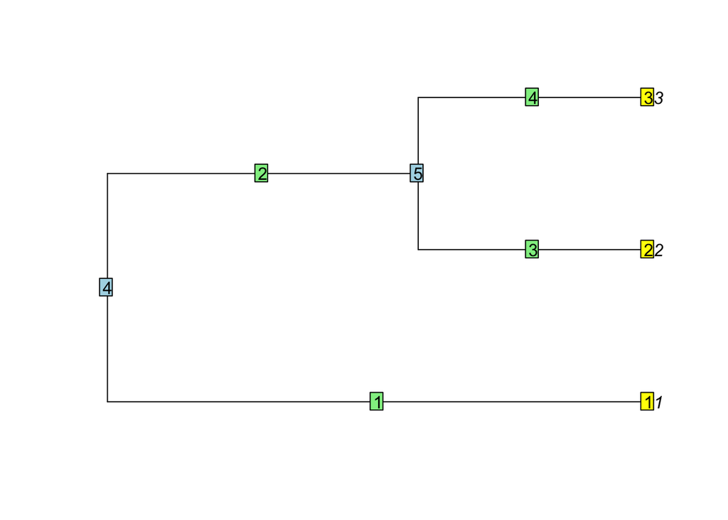

```r
set.seed(100)
tr<-pbtree(n=3, scale=1, b=1, d=0)
plot(tr)
nodelabels()
edgelabels()
tiplabels()
```

```r
# save tree file, this is optional
#write.tree(tr, file='3_taxon.tree')
```

You will need these data objects for your Ln algoritm *tr$edge*, *tr$edge.length*

```r
# tree topology
tr$edge
```

```
##      [,1] [,2]
## [1,]    4    1
## [2,]    4    5
## [3,]    5    2
## [4,]    5    3
```

```r
# branch lengths
tr$edge.length
```

```
## [1] 1.0000000 0.5740947 0.4259053 0.4259053
```